# Numerical instability, and what to do about it, as seen with Wilkinson’s polynomial

JMA

September 1, 2017

The Wilkinson polynomial is a a computer scientist’s computational nightmare; an object lesson in how badly wrong things can go due to the effects of finite numerical accuracy. In this blog we’ll show just how bad this can be. We can use this as a sensitive test for different numerical encodings (e.g. IEEE 754), as we will demonstrate with encodings for web transport.

### A Wilkinson polynomial of degree 20

The Wilkinson polynomial has the nice property that we know its values over a subset of the natural numbers. To be precise, by construction it has integer roots from 1 to $n$, so for $w_n(x) = 0\ \mbox{for}\ x = 1 \ldots n$. The best way to evaluate the polynomial this function is to compute this expression $w_n(x) = \prod_{k=1\ldots n}(x-k)$

This is convenient because each term in the product is a small number, of the order of the degree of the polynomial.

```r
wilkinson.products <- function(x, nn=20) {
    w <- function(x, n=nn) {
        v <- rep(x, n) - seq(n)  # The terms in the polynomial product (x-1), (x-2), ...
        Reduce( '*', v)
    }
sapply(x, w)
}
```

Alternatively writing the terms explicitly for this polynomial reveals the problem; it consists of huge terms of alternating signs.

### Generating Wilkinson polynomial coefficients

To look into this further, here are functions that generate the coefficients for any degree Wilkinson polynomial explicitly building the coefficients for each term.

```r
prod.of.terms <- function(n){
  # n - number of terms to generate.
  prod.of.terms.aux(c(1L, -1L), 1+ seq(1, n))
}

prod.of.terms.aux <- function(coefs, root.l) {
    # coefs  - the partial coefficient results
    # root.l - list of the multipliers to the coefficients.  Recur on this.
    if ( length(root.l) == 1) {
        return( coefs )
    } else {
        return(prod.of.terms.aux(add.poly.term(coefs, root.l[1]), root.l[-1]))
    }
}

# Build a polynomial by multiplying a new (x - b) term
# poly.coefs [1 a_1 ... a_n]
# new.term    b
# product
#    [1 a_1*b a_2 + a_1*b ... a_n*b]
add.poly.term.int <- function(poly.coefs, new.term) {
    c(poly.coefs, 0L) + c(0L, -as.integer(new.term) * poly.coefs )   # once integer overflow occurs, returns NA.
}

# Same but dont restrict coefs to ints.  Rounding will occur
add.poly.term <- function(poly.coefs, new.term) {
    c(poly.coefs, 0L) + c(0L, -new.term * poly.coefs )   # once integer overflow occurs, returns NA.
}
```

For example we generate the coefficients for the polynomial of degree 20, to compare with the example above.

```r
prod.of.terms(20)
```

```
##  [1]  1.000000e+00 -2.100000e+02  2.061500e+04 -1.256850e+06  5.332795e+07
##  [6] -1.672281e+09  4.017177e+10 -7.561112e+11  1.131028e+13 -1.355852e+14
## [11]  1.307535e+15 -1.014230e+16  6.303081e+16 -3.113336e+17  1.206648e+18
## [16] -3.599980e+18  8.037812e+18 -1.287093e+19  1.380376e+19 -8.752948e+18
## [21]  2.432902e+18
```

#### Evaluate the Wilkinson Polynomial

```r
# Use the computed coefficients and evaluate the polynomial
# eps - bias in coefficients.
evaluate.wilkinson  <- function(x, n) {
    individual.terms <- prod.of.terms(n) * powers.of.x(x, n)
    sum(individual.terms)
}
#a vector of powers of x, computed recursively
powers.of.x <- function(x, n) {
    if (n == 0)
        return(1)  # the zeroth power of x
    else
        return(c(x * powers.of.x(x, n-1), 1))
}
```

As the polynomial degree increases there are fewer values where it evaluates correctly to zero, until for degree 20, no values are correct. They all should be equal to zero.

```r
for (z in 12:19 ) {
    cat(z, ': ', sapply(1:z, function(x) evaluate.wilkinson(x, 1+z)), '\n')
    cat('\n')
}
```

```
## 12 :  0 0 0 0 0 0 0 0 0 0 0 0
##
## 13 :  0 0 0 0 0 0 0 0 0 0 -6 0 29
##
## 14 :  0 0 0 0 0 0 -3 0 -51 0 -325 0 -232 -1920
##
## 15 :  0 0 0 0 -1 0 -51 0 569 256 3776 0 29696 -71424 -132736
##
## 16 :  0 0 10 0 -14 1280 2510 0 -34968 -2048 -4288 360448 -29440 292864 -4028160 0
##
## 17 :  0 0 -250 0 -3772 -38912 27520 0 46336 501760 -2310656 -9920512 14393344 -2009088 -316420096 0 14708736
##
## 18 :  -16 0 -3034 8192 81536 -212992 -379904 393216 10645504 -22118400 18599936 -186007552 285487104 -584228864 3656994816 14680064 18725023744 -11578023936
##
## 19 :  1184 10240 -138624 -360448 722944 -13336576 -28213248 -54788096 -412925952 -34308096 -1947484160 -12233801728 1411268608 -23352213504 -59533377536 -5962203136 410167738368 -2.873084e+12 2.80312e+12
```

What happens for the same, but send the coefficients on a `json` round-trip. We should see the same values, but we see once the rounding errors occur, the `json` conversion exacerbates things.

```r
library(jsonlite)
evaluate.wilkinson.json  <- function(x, n) {
    coefs <- fromJSON(toJSON( prod.of.terms(n))) * powers.of.x(x, n)
    sum(coefs)
}

for (z in 12:19 )
    cat(format(sapply(1:z, function(x) evaluate.wilkinson.json(x, 1+z)), width = 15), '\n\n')
```

[output not shown]

#### Transfering binary payloads, a better way to travel

Google’s *Protocol Buffers* convert language-specific data structures to a universal binary transfer format. It has interfaces in several languages, but not `R`. Fortunately `RProtoBuf` wraps *Protocol Buffers*, and goes a step further, to generate protocol payload conversion descriptions (as contained in `.proto` files) dynamically, hiding the machinery needed with other languages.

```r
if (!("RProtoBuf"  %in% .packages(all=TRUE)) ) {
    install.packages("RProtoBuf")
}
library(RProtoBuf)
```

On the Mac you may instead get an error during install:

```
   checking google/protobuf/stubs/common.h usability... no
   checking google/protobuf/stubs/common.h presence... no
   checking for google/protobuf/stubs/common.h... no
   configure: WARNING: Protobuf headers not found with default CXXFLAGS and CPPFLAGS, manually trying /usr/local/include
```

This fails when `pkg-config` doesn’t find include files that are missing. This is because the `RProtobuf` install requires your machine already to have Google’s *Protocol Buffers* installed from which it gets these files. To find out if they are there already, see if the compiler `protoc` runs at the command line. If it works you should get something like this:

```bash
protoc --version
```

```
## libprotoc 3.4.0
```

If instead the command isn’t recognized, you need to install the `c++` version of [*Protocol Buffers*](https://developers.google.com/protocol-buffers/) from [its github repository](https://github.com/google/protobuf.git). Be forewarned that you may discover that this takes more than just a few steps since it requires an extensive tool-chain. Follow the `README.md` file in the `src` directory, which has you run the `./autogen.sh` file in the root directory, then run `./configure`.

Note: On the Mac you will need several binaries that come installed with the *command line tools*, which come with Apple’s *XCode* development environment. Moreover, the configure command requires `bazel`, which you can install with `brew`, the Mac package install tool, which you can get from

> /usr/bin/ruby -e “$(curl -fsSL https://raw.githubusercontent.com/Homebrew/install/master/install)”

Of course for this you need `ruby` installed. Then you can

> brew install bazel

and any other missing build tools, including glibtool (a replacement for Mac’s native libtool). Don’t worry eventually you’ll get everything needed. Does this remind you of the story *[If you give a Mouse a Cookie?](https://en.wikipedia.org/wiki/If_You_Give_a_Mouse_a_Cookie)* You get the picture. :)

### How well does the protocol buffer do with numerical errors

Same, but send the coefficients on a protocol buffer round-trip

```r
evaluate.wilkinson.buffers  <- function(x, n) {
  coefs <- unserialize_pb(serialize_pb( prod.of.terms(n), NULL)) * powers.of.x(x, n)
  sum(coefs)
}
```

#### compare the json serialized roots with the internal values

```r
wilkinson.errs.json <- function(the.range= 1:10, poly.degree=17) {
  errs <- abs(sapply(the.range, function(x)evaluate.wilkinson(x,poly.degree)) -
                sapply(the.range, function(x)evaluate.wilkinson.json(x,poly.degree)))
  list(the.range, errs)
}

# compare the protocol buffer serialized roots with the internal values
wilkinson.errs.pb <- function(the.range= 1:10, poly.degree=17) {
  errs <- abs(sapply(the.range, function(x)evaluate.wilkinson(x,poly.degree)) -
                sapply(the.range, function(x)evaluate.wilkinson.buffers(x,poly.degree)))
  list(the.range, errs)
}
```

When we plot the “round trip” errors for `json` and protocol buffers, we see that unlike with `json`, the protocol buffer transformations preserve the values before and after encoding steps.

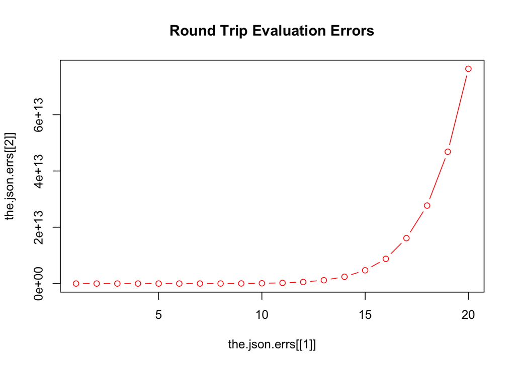

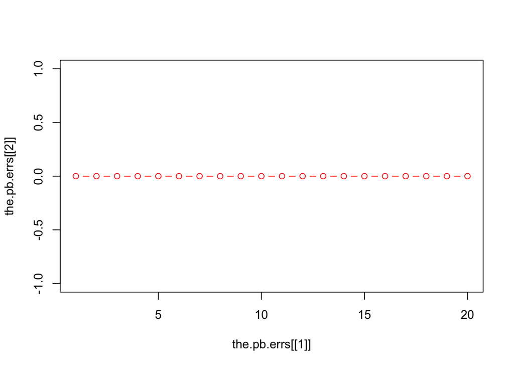

So at the end of the day the limits are imposed by `R`’s own numerical limitations, as the Wilkinson polynomial demonstrates. `R`’s numerics are an implementation of the widely adopted IEEE 754 standard. The precision of an `R` double on an IEEE 754-compliant platform (e.g. an x86) is not quite 16 decimal digits, For details see [Numerical Characteristics of the Machine](https://www.rdocumentation.org/packages/base/versions/3.4.1/topics/.Machine) in the R documentation. Here, for example are how to find the smallest real and largest integer values.

```r
.Machine$double.eps
```

```
## [1] 2.220446e-16
```

```r
.Machine$integer.max
```

```
## [1] 2147483647
```

```r
# which is just equal to
2^31 - 1
```

```
## [1] 2147483647
```

#### Loss-free data serialization frameworks

*Protocol buffers* aren’t the only way to transfer data losslessly. It is a common need with remote function calls, and comes up with cross-platform services such as *Restful HTTP*. They all share a commmon model, of starting with an *interface definition file* either manually or dynamically generated, then supporting compilers in a variey of languages to read and write contents according to that definition.

[Thrift](https://thrift.apache.org/) is a full featured protocol, created by Facebook, and now part of Apache. An alternative is the slightly more economical [Apache Avro](http://avro.apache.org/docs/current/). Microsoft has its own very rich offering with [Bond](https://github.com/Microsoft/bond/). Sadly only *protocol buffers* has an `R` version. As for `json` based serialization, as an easy and efficient alternative, since `json` uses a text conversion rather than binary encoding, it suffers losses with numeric data, as we’ve demonstrated.